Práctica 5

```r
library(MASS)
library(ggplot2)
library(dplyr)
library(tidyr)
library(prob)
library(readr)
library(stringr)
```

Ejercicios 1) Considérese el experimento de lanzar 20 veces una moneda y obtener la secuencia: H,T,H,H,T,H,H,T,H,H,T,T,H,T,T,T,H,H,H,T.

1. Tabular los resultados del experimento anterior encontrando las proporciones de H y T en los 20 lanzamientos.

```r
nbrLanz<-(1:20)
nbrRestlLanz<-c("H","T","H","H","T","H","H","T","H","H","T","T","H","T","T","T","H","H","H","T")
tab<-cbind(nbrLanz, nbrRestlLanz)
tab<-data.frame(nbrLanz, nbrRestlLanz)

nbrHeads<-sum(tab=="H")
nbrTails<-sum(tab=="T")
nbrTotal<-nrow(tab)
```

```r
nbrPropH<-c(nbrHeads/nbrTotal)
nbrPropH
```

```
## [1] 0.55
```

```r
nbrPropT<-c(nbrTails/nbrTotal)
nbrPropT
```

```
## [1] 0.45
```

2. Graficar las proporciones con barplot y plot.

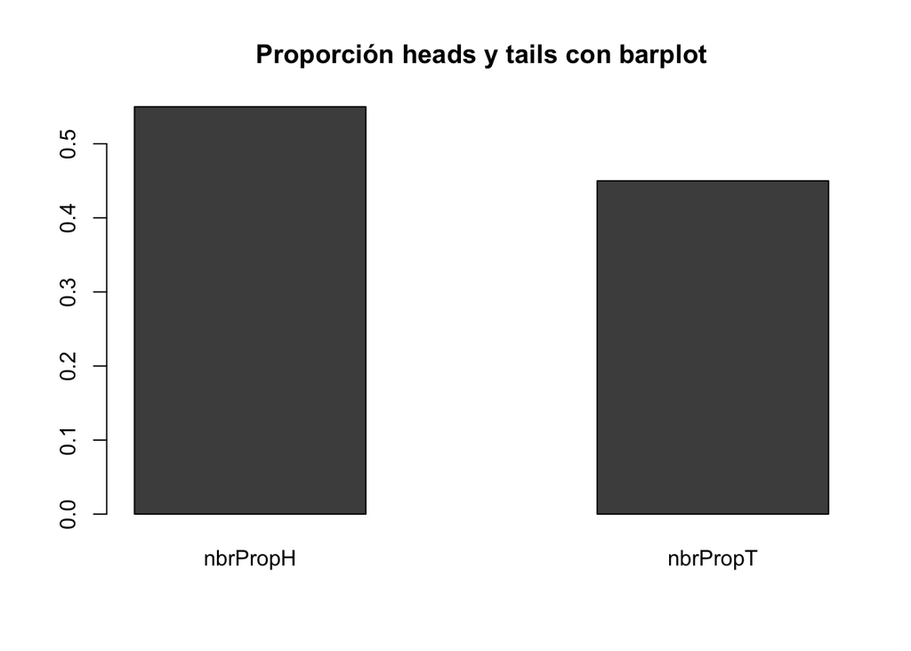

```r
arrPoporciones<-cbind(nbrPropH, nbrPropT)
barplot(arrPoporciones, beside=TRUE, main = "Proporción heads y tails con barplot")
```

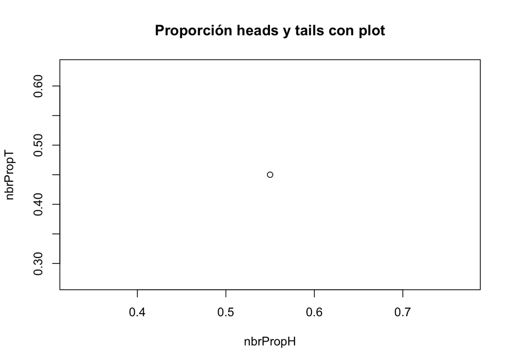

```r
plot(arrPoporciones, main="Proporción heads y tails con plot")
```

2) Para el dataset analizado anteriormente y que se creó: log_mammals realizar:

a)Para datos cuantitativos es común realizar diagramas de tallos y hojas. Investigar la interpretación de estos diagramas y usar la función stem del paquete base de R para realizar tales diagramas a las variables log_body y log_brain e interpretarlas.

Un diagrama de tallo y hojas, ofrece la posibilidad de ver la distribución de frecuencia y ordenación de los datos.

En este caso, todo está distribuido entre -4 y 8, y en el 0 se concentra la mayor cantidad de datos

```r
log_mammals <- log(mammals)
stem(log_mammals$body)
```

```
##
##   The decimal point is at the |
##
##   -4 | 36
##   -2 | 880863311
##   -0 | 639763211
##    0 | 00333557912233344459
##    2 | 347366
##    4 | 00114612335
##    6 | 1338
##    8 | 8
```

En el siguiente diagrama se ve un rango de valores similar y también una concentración mayor en el 0

```r
stem(log_mammals$brain)
```

```
##
##   The decimal point is at the |
##
##   -2 | 0
##   -0 | 4219
##    0 | 00269901344677899
##    2 | 1445555789022789
##    4 | 01467781122228
##    6 | 00012552
##    8 | 47
```

2. scatterplot coloreando diferente a cada grupo que se creó: mamífero pequeño y mamífero grande con la variable size_body.

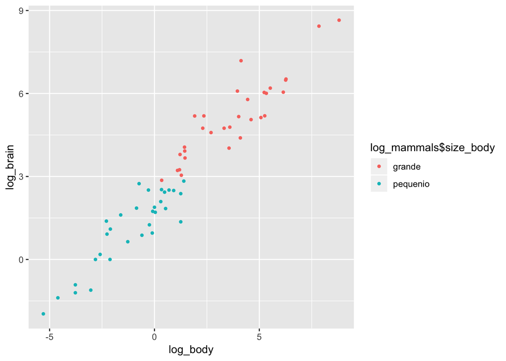

```r
colnames(log_mammals) <- c('log_body', 'log_brain')
mediana_body <- median(log_mammals$log_body)
mediana_brain <- median(log_mammals$log_brain)
log_mammals$size_body <- ifelse(log_mammals$log_body >= mediana_body, "grande", "pequenio")
log_mammals$size_body <- ifelse(log_mammals$log_brain >= mediana_brain, "grande", "pequenio")

dfMammalsBody <- data.frame(medida = rep('body', times=nrow(mammals)),
                            mammal=rownames(log_mammals),
                            valor = log_mammals$log_body)
dfMammalsBrain <- data.frame(medida = rep('brain', times=nrow(mammals)),
                            mammal=rownames(log_mammals),
                            valor = log_mammals$log_brain)

dfMammalsGG <- rbind(dfMammalsBody, dfMammalsBrain)

ggplot(log_mammals)+geom_point(aes(x=log_body, y=log_brain, color=log_mammals$size_body), size=1)
```

c) Instalar el paquete dplyr para colocar los datos en un formato long y se pueda graficar con el paquete de ggplot2 con la función gather el dataframe log_mammals. Después de instalar tal paquete, realizar mismo enunciado que a) pero con geom_points y paquete ggplot2.

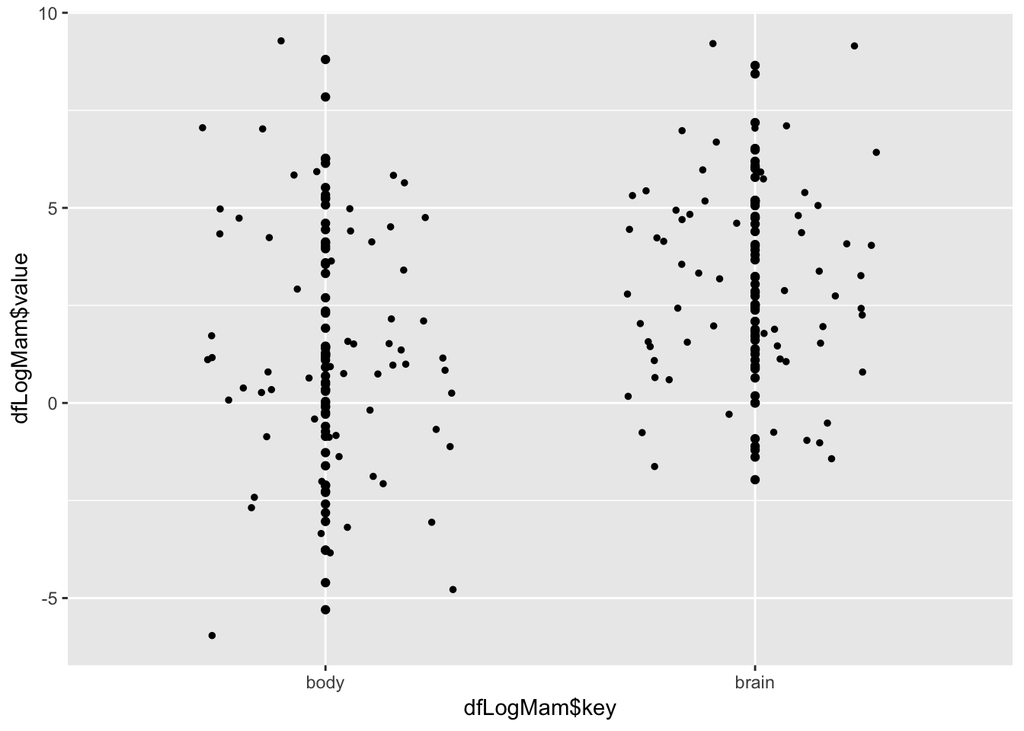

```r
logmammals <- log(mammals)

dfLogMam <- gather(logmammals)

ggplot(dfLogMam)+geom_point(aes(x=dfLogMam$key, y=dfLogMam$value))+
geom_jitter(aes(x=dfLogMam$key, y=dfLogMam$value), position=position_jitter(width=.3, height=.8),size=1)
```

d) Calcular estadísticas como el promedio, mediana, máximo y mínimo por grupos de mamífero pequeño y mamífero grande con dplyr y funciones como group_by, sumarise y el operador %>% (pipe). Ver como ayuda: Data Wrangling with dplyr and tidyr o Data Transformation with dplyr o bien como ejemplo de uso: https://genomicsclass.github.io/book/pages/dplyr_tutorial.html u otro tutorial en la red de dplyr ¿qué mamíferos en cada grupo están en los tres primeros lugares (pensando que se ordenan de forma decreciente en log_brain)?.

```r
log_mammals <- log(mammals)
colnames(log_mammals) <- c('log_body','log_brain')

mediana_body <- median(log_mammals$log_body)
mediana_brain <- median(log_mammals$log_brain)
log_mammals$size_body <- ifelse(log_mammals$log_body >= mediana_body, "grande", "pequenio")
log_mammals$size_brain <- ifelse(log_mammals$log_brain >= mediana_brain, "grande", "pequenio")

log_mammals %>%
            group_by(size_brain) %>%
            summarise(avg_log_mammals_brain = mean(log_brain),
                      med_log_mammals_brain = median(log_brain),
                      min_log_mammals_brain = min(log_brain),
                      max_log_mammals_brain = max(log_brain))
```

```
## # A tibble: 2 x 5
##   size_brain avg_log_mammals… med_log_mammals… min_log_mammals…
##   <chr>                 <dbl>            <dbl>            <dbl>
## 1 grande                 5.14             5.13             2.86
## 2 pequenio               1.14             1.39            -1.97
## # ... with 1 more variable: max_log_mammals_brain <dbl>
```

```r
dfMammalsBody <- data.frame(medida = rep('body', times=nrow(mammals)),
                            mammal=rownames(log_mammals),
                            log_body = log_mammals$log_body)
dfMammalsBrain <- data.frame(medida = rep('brain', times=nrow(mammals)),
                            mammal=rownames(log_mammals),
                            log_brain = log_mammals$log_brain)

dfMammalsBrain$size_brain = ifelse(log_mammals$log_brain >= mediana_brain, "grande", "pequenio")
```

Los primeros 3 lugares son: Lesser short-tailed shrew, Little brown bat y Big brown bat:

```r
dfMammalsBrain %>%
    select(mammal, log_brain, size_brain) %>%
    arrange(log_brain) %>%
    head
```

```
##                      mammal  log_brain size_brain
## 1 Lesser short-tailed shrew -1.9661129   pequenio
## 2          Little brown bat -1.3862944   pequenio
## 3             Big brown bat -1.2039728   pequenio
## 4                Musk shrew -1.1086626   pequenio
## 5                     Mouse -0.9162907   pequenio
## 6           Star-nosed mole  0.0000000   pequenio
```

Los mamíferos en los primeros lugares son: African elephant, Asian elephant y Human:

```r
dfMammalsBrain %>%
    select(mammal, log_brain, size_brain) %>%
    arrange(desc(log_brain)) %>%
    head
```

```
##             mammal log_brain size_brain
## 1 African elephant  8.650325     grande
## 2   Asian elephant  8.434464     grande
## 3            Human  7.185387     grande
## 4          Giraffe  6.522093     grande
## 5            Horse  6.484635     grande
## 6            Okapi  6.194405     grande
```

5. Crea una nueva variable r que sea el cociente entre brain y body. Ordena en orden creciente el dataset de mammals de acuerdo a esta nueva variable. ¿Qué mamíferos tienen los cocientes más grandes?

```r
dfMammalsBody <- data.frame(medida = rep('body', times=nrow(mammals)),
                        mammal=rownames(mammals),
                        valor_body= mammals$body)
dfMammalsBrain <- data.frame(medida = rep('brain', times=nrow(mammals)),
                        mammal=rownames(mammals),
                        valor_brain= mammals$brain)

dfMammalsGG<-cbind(dfMammalsBody, dfMammalsBrain)
dfMammalsGG<-dfMammalsGG[,-1:-2]
dfMammalsGG$r=dfMammalsGG$valor_brain/dfMammalsGG$valor_body

dfMammalsGG %>%
    select(mammal, r, valor_brain, valor_body) %>%
    arrange(desc(r)) %>%
    head
```

```
##                      mammal        r valor_brain valor_body
## 1           Ground squirrel 39.60396        4.00      0.101
## 2                Owl monkey 32.29167       15.50      0.480
## 3 Lesser short-tailed shrew 28.00000        0.14      0.005
## 4             Rhesus monkey 26.32353      179.00      6.800
## 5                    Galago 25.00000        5.00      0.200
## 6          Little brown bat 25.00000        0.25      0.010
```

¿y cuáles los más pequeños?

```r
dfMammalsGG %>%
    select(mammal, r, valor_brain, valor_body) %>%
    arrange(r) %>%
    head
```

```
##             mammal         r valor_brain valor_body
## 1 African elephant 0.8584310      5712.0     6654.0
## 2              Cow 0.9096774       423.0      465.0
## 3              Pig 0.9375000       180.0      192.0
## 4  Brazilian tapir 1.0562500       169.0      160.0
## 5    Water opossum 1.1142857         3.9        3.5
## 6            Horse 1.2571977       655.0      521.0
```

6. Usando e) realiza un scatterplot de r vs body.

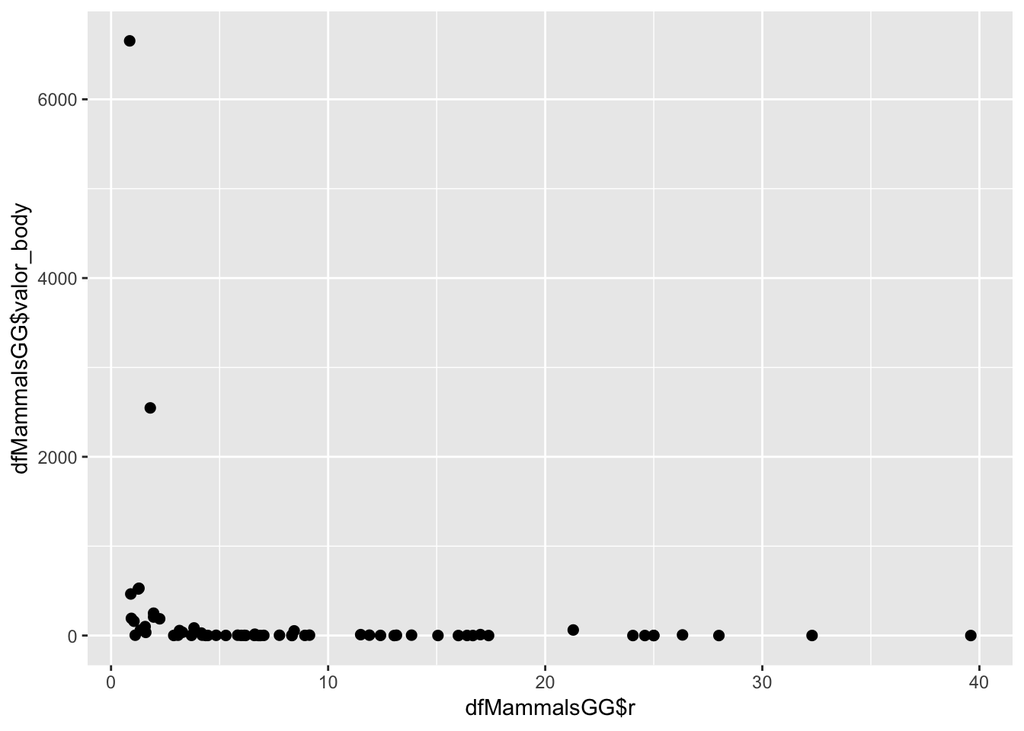

```r
ggplot(dfMammalsGG)+geom_point(aes(x=dfMammalsGG$r, y=dfMammalsGG$valor_body), size=2)
```

3) Considérese el dataset randu (ejecutar ?randu para una descripción):

1. Usar la función mean para calcular la media muestral en cada uno de los números que forman la tripleta: x, y, z. Asimismo usar la función var para calcular una matriz de varianzas y covarianzas muestral.

```r
sapply(randu,mean)
```

```
##         x         y         z
## 0.5264293 0.4860531 0.4809547
```

```r
var(randu)
```

```
##              x            y            z
## x  0.081231885 -0.004057683  0.004637656
## y -0.004057683  0.086270206 -0.005148432
## z  0.004637656 -0.005148432  0.077860433
```

2. Queremos ver la distribución del promedio por renglón de cada observación del dataset randu, para esto utilizar la función de apply para calcular tal promedio, alternativamente usar rowMeans.

```r
distprom1 <- apply(randu, MARGIN=1, FUN=mean)
distprom1
```

[output not shown]

[output cut: 79 more lines]

[output not shown]

3. Utilizar la función hist del paquete base para calcular un histograma con los breaks definido por tal función

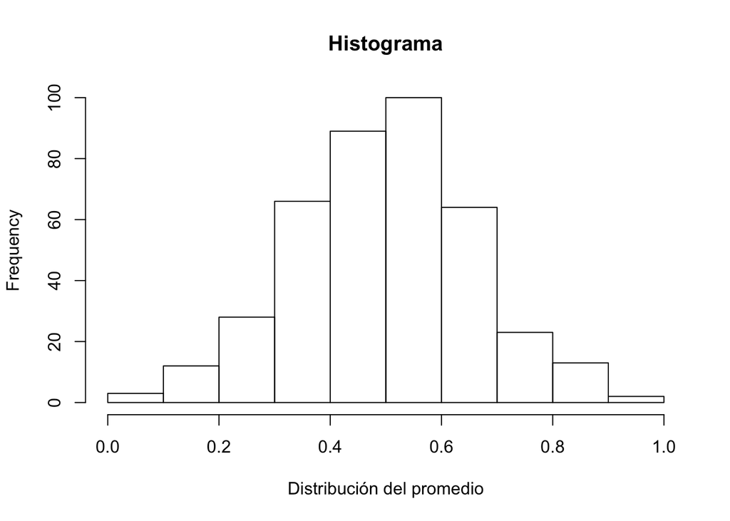

```r
hist(distprom1, main="Histograma", xlab="Distribución del promedio")
```

d) Calcular sus propios breaks y volver a graficar el histograma con hist y con geom_histogram del paquete ggplot2.

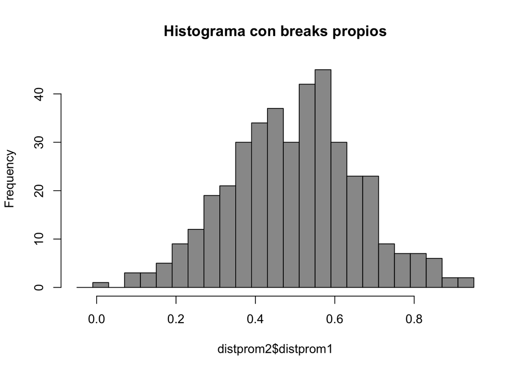

```r
dif <- .05
width <- .04
nbrMinimo <- min(distprom1) - dif
nbrMaximo <- max(distprom1) + dif
cortes <- seq(nbrMinimo, nbrMaximo, by = width)

distprom2<-data.frame(distprom1)
distprom2$intervalo <- cut(distprom2$distprom1, breaks = cortes)

hist(distprom2$distprom1, breaks=cortes,
    main="Histograma con breaks propios", col='gray60')
```

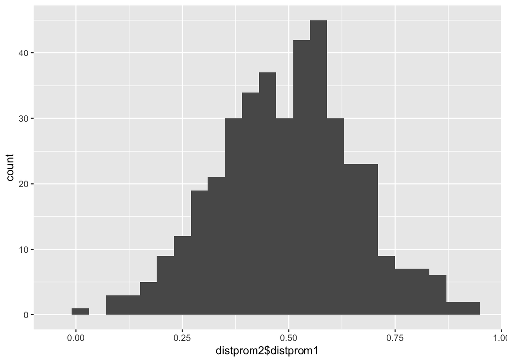

```r
ggplot(data=distprom2)+geom_histogram(aes(x=distprom2$distprom1), breaks=c(cortes))
```

e) Utilizar la función qqnorm para comparar los cuantiles de una distribución normal con la distribución de las medias muestrales obtenidos en el inciso b). Sólo de forma visual ¿qué se puede concluir sobre la distribución de las medias muestrales calculadas en b)? (puedes añadir una línea al gráfico con qqline).

Se puede concluir que las medias se distribuyen normalmente pues se aprecia visualmente una recta diagonal

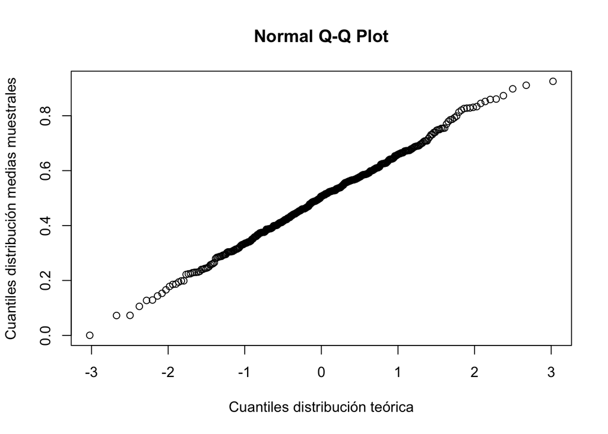

```r
qqnorm(distprom1,xlab="Cuantiles distribución teórica", ylab="Cuantiles distribución medias muestrales")
```

4) Realizar gráficas con el comando qqplot para comparar 2 distribuciones de datos

En el primera gráfica comparamos una gráfica normal contra una t student, ambas distribuciones tienen un comportamiento similar, pues los valores están muy cerca a la línea recta, únicamente en los extremos se alejan los valores

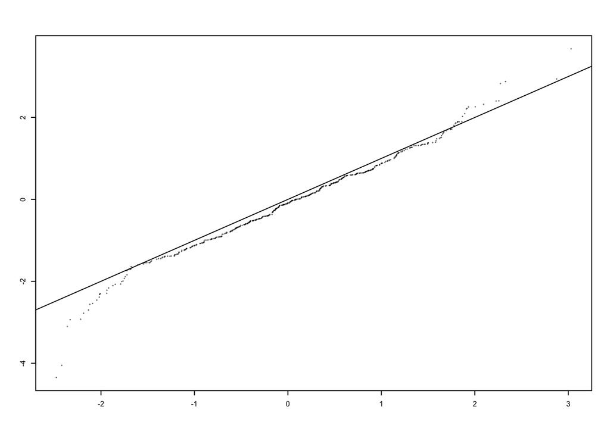

```r
n<-500
set.seed(2000)
par(cex=0.5) #control size of labels
datos<- qqplot(rnorm(n), rt(n,df=10), cex=.1, xlab='', ylab='')
abline(0,1) #recta a 45 grados, sirve de apoyo para realizar comentarios
```

En la segunda gráfica vemos que las distribuciones están muy alejadas (gráfica normal vs chi cuadrada)

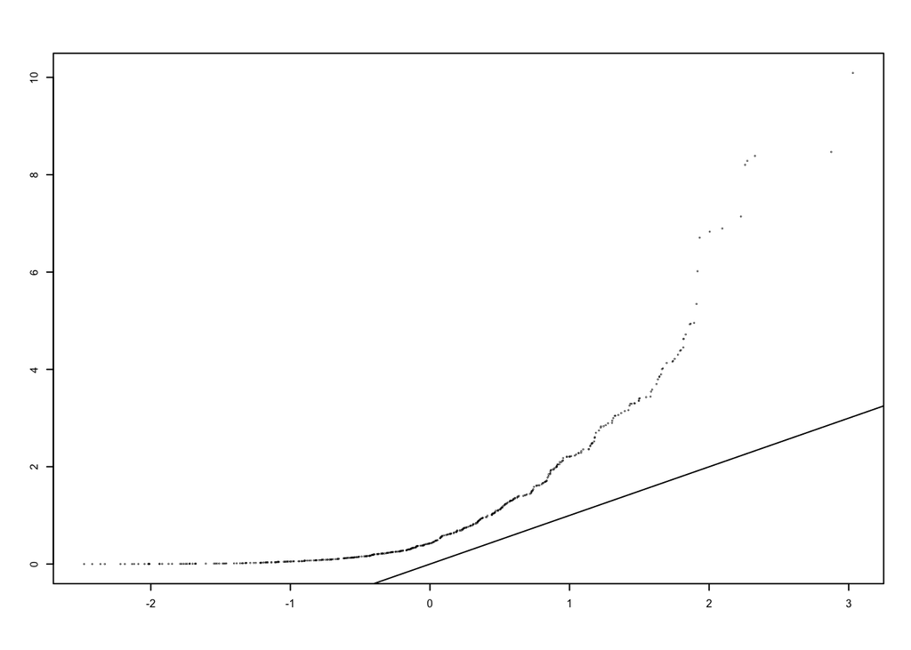

```r
n<-500
set.seed(2000)
par(cex=0.5) #control size of labels
datos<- qqplot(rnorm(n), rchisq(n,df=1), cex=.1, xlab='', ylab='')
abline(0,1) #recta a 45 grados, sirve de apoyo para realizar comentarios
```

1) Supóngase que el tiempo (en minutos) que una persona espera el Metrobús los días de semana sigue una distribución uniforme dada por,
$$f(x) = \begin{cases}
\frac{1}{12} &amp; \text{si } 0 \leq x \leq 12,\\
0 &amp; \text{en otro caso}
\end{cases}$$
a) ¿Cuál es la probabilidad que una persona espere menos de $6$ minutos?.

```r
a=0
b=12
punif(6,min = a, max=b)
```

```
## [1] 0.5
```

2. ¿Su tiempo medio de espera?

```r
a=0
b=12
mu=(a+b)/2
mu
```

```
## [1] 6
```

¿su desviación estándar?.

```r
sd=sqrt(((b-a)**2)/12)
sd
```

```
## [1] 3.464102
```

2. Considérese lanzamientos de una moneda no cargada. Sea $X$ la variable aleatoria que cuenta el número de águilas en $10$ lanzamientos. Calcular en R la probabilidad $P(X \geq 3)$ con la función pbinom y dbinom, el número medio de águilas y su desviación estándar.

```r
n=10
p=.5
#con dbminom
1-(dbinom(0,size=n, prob=p)+dbinom(1,size=n, prob=p)+dbinom(2,size=n, prob=p))
```

```
## [1] 0.9453125
```

```r
#con pbinom
1-pbinom(2,size=n, prob=p)
```

```
## [1] 0.9453125
```

```r
#número de águilas
mu=n*p
mu
```

```
## [1] 5
```

```r
#desviación estándar
sd=sqrt(n*p*(1-p))
sd
```

```
## [1] 1.581139
```

3. Considérese una población de votantes en la ciudad de México. Se reporta que la proporción de votantes que favorecen al candidato del partido Naranja es igual a $0.40$. Dada una muestra aleatoria de $200$ votantes, ¿cuál es la probabilidad de que más de la mitad de ellos tengan intención de voto por el candidato naranja? Usar:
1. pbinom

```r
n=200
pfav=.4
pbinom(n/2, size=n, prob=pfav, lower.tail = F)
```

```
## [1] 0.001684787
```

2. El teorema del límite central y pnorm considerando lo que se conoce como corrección por continuidad: si $B$ es variable aleatoria binomial con $\mu$ y $\sigma$ entonces $P(B=k) = P(k-0.5&lt;X&lt;k+0.5)$ con $X$ variable aleatoria normal $N(\mu,\sigma)$ y $k$ un número entero no negativo.

```r
n=200
pfav=.4
mu=n*pfav
sig=sqrt(n*pfav*(1-pfav))
pnorm((n/2)+.5, mu, sig, lower.tail = F)
```

```
## [1] 0.001543596
```

4. Supongamos que el ingreso anual de un imigrante mexicano en los EUA se distribuye de forma normal con una media de $\$30,000$ y una desviación estándar de $\$10,000$ dólares. ¿Cuál es la probabilidad de que un inmigrante mexicano gane menos de $\$20,000$ dólares anuales? ¿Cuál es la probabilidad de que su ingreso sea mayor a los $\$50,000$ dólares anuales?

```r
mu=30000
sd=10000
ia1=20000
ia2=50000
#Prob de que un migrante gane menos de 20,000 anuales:
pnorm(ia1,mu,sd)
```

```
## [1] 0.1586553
```

```r
#Prob de que un migrante gane menos de 50,000 anuales:
pnorm(ia2,mu,sd, lower.tail = F)
```

```
## [1] 0.02275013
```